# Ejercicios_cap_1

Adrián Enríquez

29/4/2021

# Generación de números pseudoaleatorios en R

## Ejercicio 1.1

Sea $(X,Y)$ un vector aleatorio con distribución uniforme en el cuadrado $[-1,1]\times [-1,1]$ de área $4$.

1. Aproximar mediante simulación $P(X+Y\leq 0)$ y compararla con la probabilidad teórica.

Primero calculemos la probabilidad teórica usando la regla de Laplace, para ello notemos en el siguiente gráfico que, el área de color verde representa el area favorable, mientras que el área posible esta dada por todo el cuadrado que es de 4.

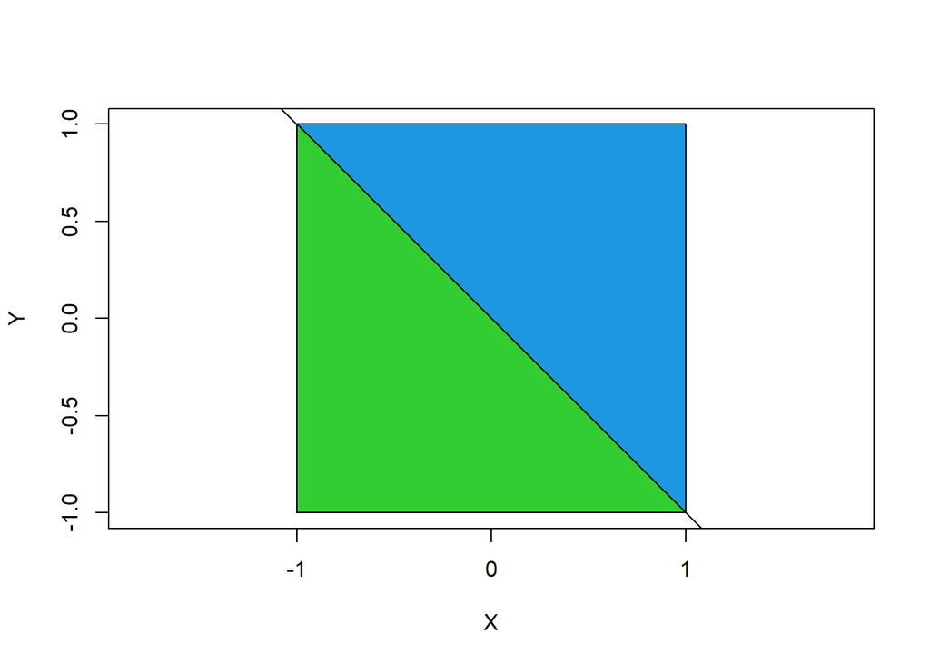

Por tanto,

$$\begin{align*}
P(X+Y\leq 0)&=\frac{\text{Área favorable}}{\text{Área posible}}\\
&=\frac{2}{4}\\
&=\frac{1}{2}
\end{align*}$$

Ahora, aproximemos el valor de la probabilidad usando simulación, con lo cual generamos 1000 valores aleatorios entre $-1$ y $1$ para $X$ e $Y$

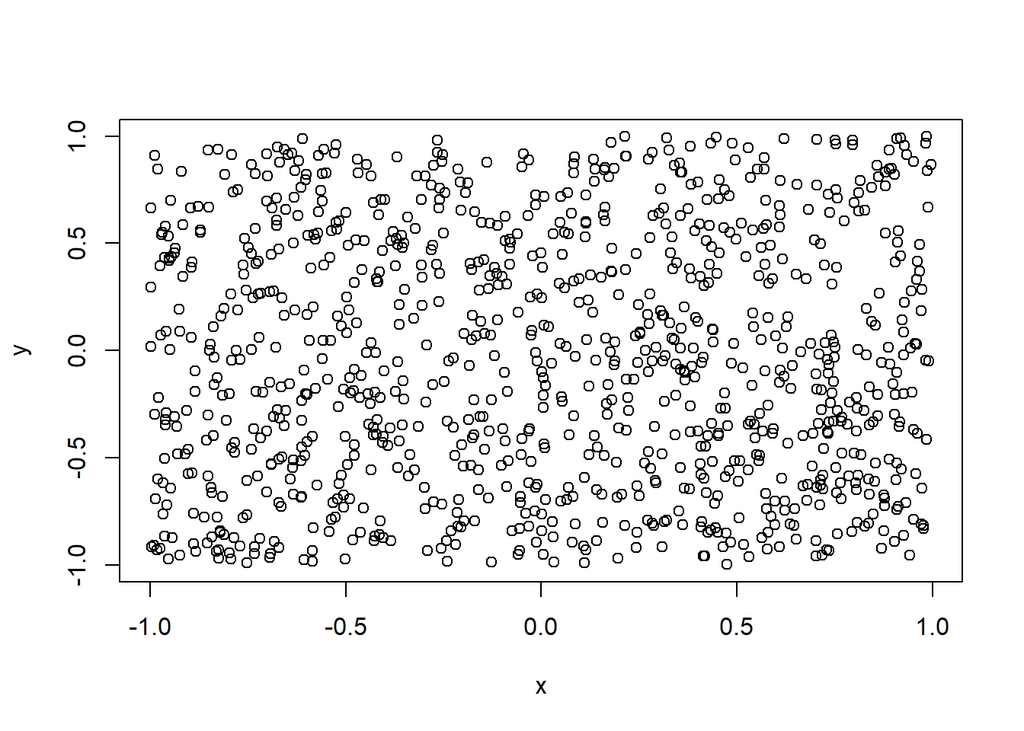

```r
set.seed(610)
nsim=1000
x<-runif(nsim,-1,1)
y<-runif(nsim,-1,1)

plot(x,y)
```

Una vez que ya hemos generado los valores, determinemos la probabilidad aproximada, para ello, determinemos cuantos puntos $X,Y$ que determinan que $X+Y\leq 0$

```r
cont<-x+y<=0 # vector booleano que tiene true si se cumple que x+y<=0 y false si no

prob_aprox<-length(cont[cont==TRUE])/length(cont)
```

Con lo cual, la probabilidad aproximada es

```r
prob_aprox
```

```
## [1] 0.489
```

2. Aproximar el valor de $\pi$ mediante simulación a partir de $P(X^2+Y^2\leq 1)$

Recordemos que el área de un círculo viene dada por $A=\pi\cdot r^2$, como en este caso, el círculo tiene radio $r=1$, entonces
$$A=\pi$$
Y como podemos notar, en el siguiente gráfico, el área favorable es el área del círculo y el área posible es el área de todo el cuadrado

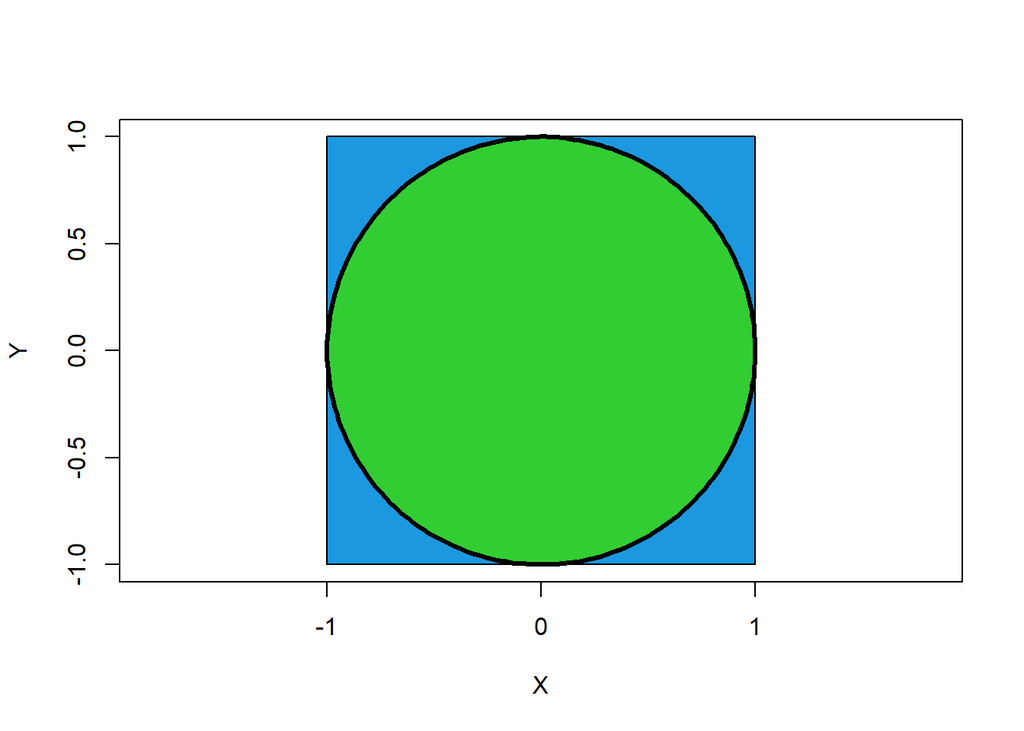

Por tanto, la probabilidad teórica es:

$$\begin{align*}
P(X^2+Y^2\leq 1)&=\frac{\text{Área favorable}}{\text{Área posible}}\\
&=\frac{\pi}{4}
\end{align*}$$

Con lo cual
$$\pi=4\cdot P(X^2+Y^2 \leq 1)$$

Por tanto, para aproximar el valor de $\pi$ usemos simulación para aproximar el valor de $P(X^2+Y^2\leq 1)$, así, de la misma manera que en el literal anterior generemos valores para $X$ e $Y$

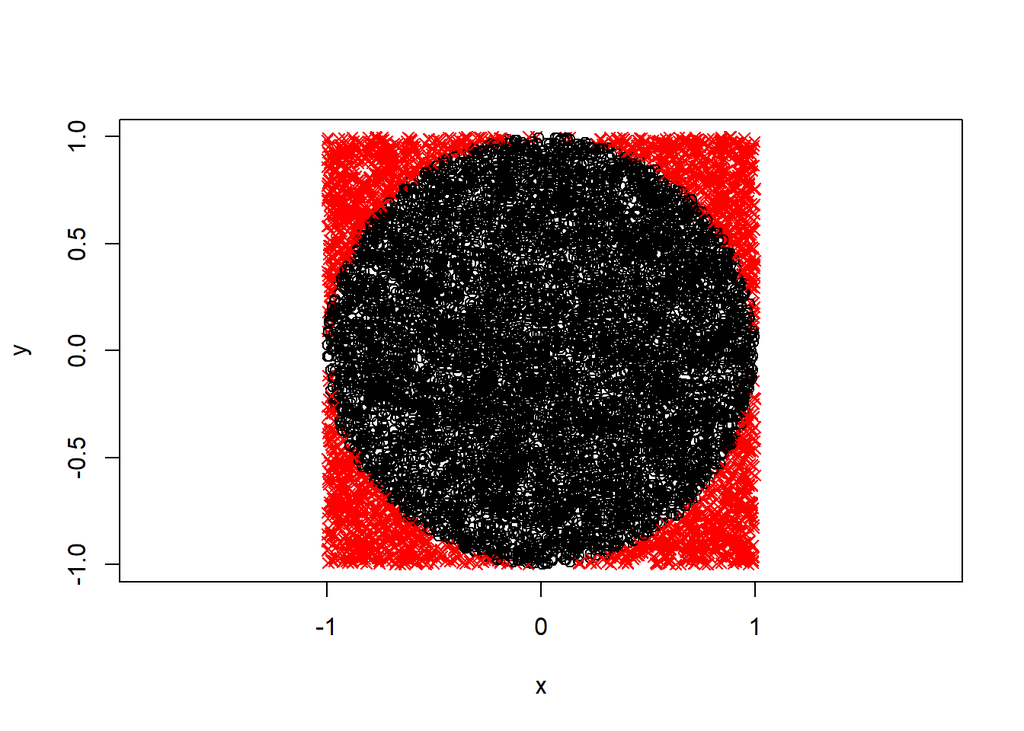

```r
nsim<-10000

x<-runif(nsim,-1,1)
y<-runif(nsim,-1,1)

color=ifelse(x^2+y^2<=1,"black","red")
simbolo<-ifelse(x^2+y^2<=1,1,4)
plot(x,y,pch=simbolo,col=color, asp=1)
```

Con lo cual, el valor de $\pi$ aproximado es

```r
cont<-x^2+y^2<=1

proba_aprox<-mean(cont)

aprox_pi<-proba_aprox*4
aprox_pi
```

```
## [1] 3.1272
```

## Ejercicio 1.2

Consideramos el experimento de Bernoulli consistente en el lanzamiento de una moneda.

1. Empleando la función sample, obtener 1000 simulaciones del lanzamiento de una moneda (0 = “cruz”, 1 = “cara”), suponiendo que no está trucada. Aproximar la probabilidad de cara a partir de las simulaciones.

```r
set.seed(610)
nsim<-1000
x<-sample(c("cruz"=0,"cara"=1),size = nsim,replace = TRUE,prob = c(0.5,0.5))
mean(x)
```

```
## [1] 0.483
```

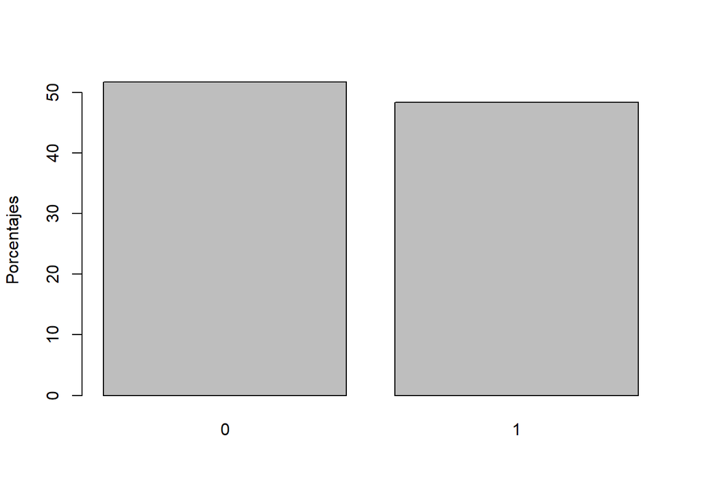

```r
barplot(100*table(x)/nsim,ylab = "Porcentajes")
```

2. En R pueden generarse valores de la distribución de Bernoulli mediante la función rbinom(nsim, size=1, prob). Generar un gráfico de lineas considerando en el eje X el número de lanzamientos (de 1 a 1000) y en el eje Y la frecuencia relativa del suceso cara (puede ser recomendable emplear la función cumsum).

```r
set.seed(610)
nsim<-1000
p<-0.4 # probabilidad del suceso cara
x<-rbinom(nsim,size = 1,p) # Simulación de una Bernoulli
mean(x)
```

```
## [1] 0.417
```

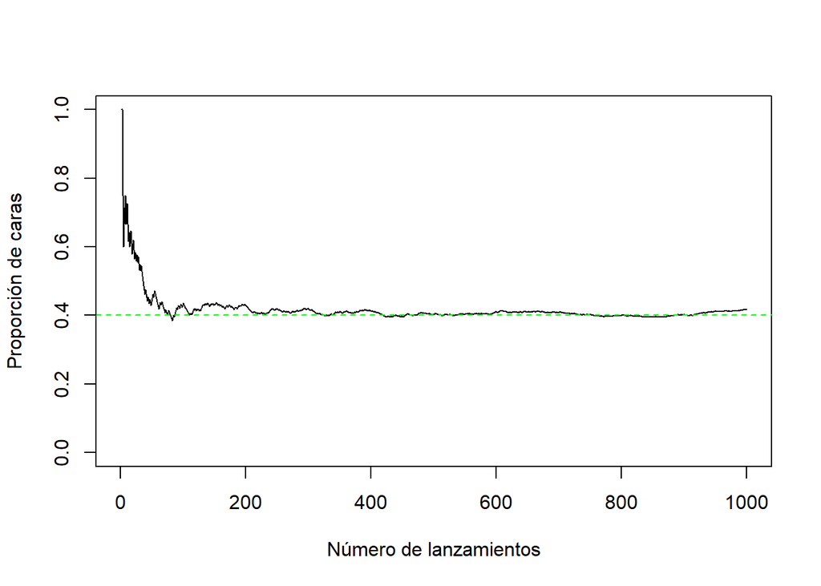

```r
n<-1:nsim
plot(n,cumsum(x)/n,type = "l",ylim = c(0,1),xlab = "Número de lanzamientos", ylab = "Proporción de caras")
abline(h=p, lty = 2,col="green")
```

## Ejercicio 1.3

Simular el paso de corriente a través del siguiente circuito, donde figuran las probabilidades de que pase corriente por cada uno de los interruptores:

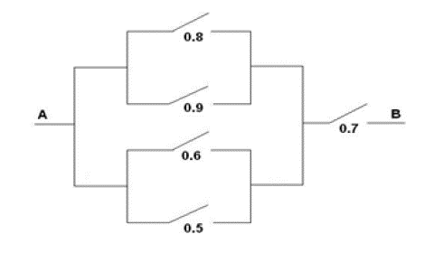

Considerar que cada interruptor es una v.a. de Bernoulli independiente para simular 1000 valores de cada una de ellas.

```r
set.seed(610)

nsim<-1000

x1<-rbinom(nsim,size = 1, 0.8) #Interruptor 1
x2<-rbinom(nsim,size = 1, 0.9) # Interruptor 2

z1<- x1 | x2 # la corriente pasa por 1 o 2

x3<-rbinom(nsim, size = 1, 0.6)
x4<-rbinom(nsim, size = 1, 0.5)

z2<- x3 | x4

x5<-rbinom(nsim, size = 1, 0.7)

z3<- z1 | z2

pasa_cor<- z3 & x5

mean(pasa_cor)
```

```
## [1] 0.703
```

## Ejercico 1.4

En 1651, el Caballero de Méré le planteó a Pascal una pregunta relacionada con las apuestas y los juegos de azar: ¿es ventajoso apostar a que en cuatro lanzamientos de un dado se obtiene al menos un seis? Este problema generó una fructífera correspondencia entre Pascal y Fermat que se considera, simbólicamente, como el nacimiento del Cálculo de Probabilidades.

1. Escribir una función que simule el lanzamiento de $n$ dados. El parámetro de entrada es el número de lanzamientos $n$, que toma el valor 4 por defecto, y la salida debe ser TRUE si se obtiene al menos un 6 y FALSE en caso contrario.

```r
lanzamiento_dado<-function(n=4)
{
  num_dado<-sample(1:6,n,replace = TRUE)
  return(6 %in% num_dado)
}

#Uso de función
lanz<-lanzamiento_dado()
lanz
```

```
## [1] TRUE
```

2. Utilizar la función anterior para simular nsim = 10000 jugadas de este juego y calcular la proporción de veces que se gana la apuesta (obtener al menos un 6 en n lanzamientos), usando n = 4. Comparar el resultado con la probabilidad teórica $1-(5/6)^n$.

```r
set.seed(610)
nsim<-10000
resultados<-replicate(nsim,lanzamiento_dado(n = 4))
```

La probabilidad teórica de ganara la apuesta es

```r
prob_teor<-1-(5/6)^4
prob_teor
```

```
## [1] 0.5177469
```

Mientras que la aproximada por simulación es

```r
prob_aprox<-mean(resultados)
prob_aprox
```

```
## [1] 0.5147
```

# Análisis de la calidad de un generador

Considera el generador congruencial definido por:

$$\begin{align*}
x_{n+1}&=(5x_n+1)\mod 512\\
u_{n+1}&=\frac{x_{n+1}}{512},\hspace{0.3 cm} n=0,1,\ldots
\end{align*}$$
(de ciclo máximo).

1. Generar 500 valores de este generador (utilizar el algoritmo implementado en el fichero RANDC.R), obtener el tiempo de CPU, representar su distribución mediante un histograma (en escala de densidades) y compararla con la densidad teórica.

```r
source("Functions/RANDC.R")
initRANDC(610,a=5,c=1, m=512)
nsim<-500

#Obtención del tiempo de CPU
system.time(u<-RANDCN(n=nsim))
```

```
##    user  system elapsed
##    0.02    0.00    0.02
```

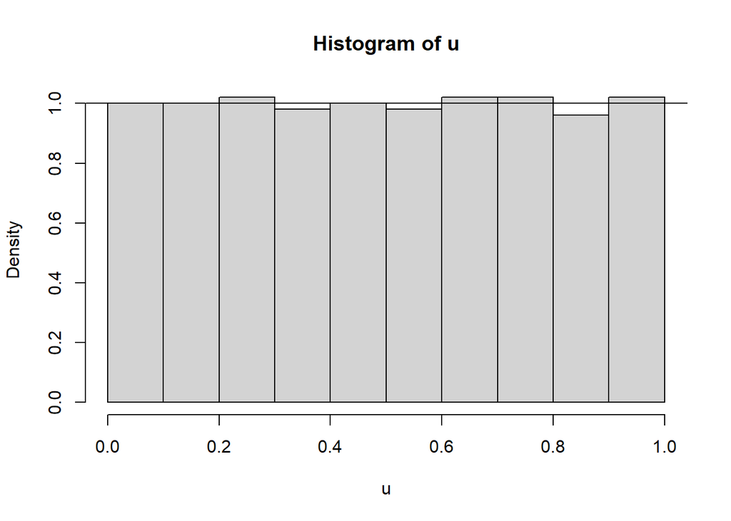

```r
#Representación en un histograma
hist(u,freq = FALSE)
abline(h=1) # densidad teórica
```

2. Calcular la media de las simulaciones (mean) y compararla con la teórica.

La media de las simulaciones es

```r
mean(u)
```

```
## [1] 0.4998203
```

Mientras que la media teórica es $0.5$

3. Aproximar (mediante simulación) la probabilidad del intervalo $(0.4; 0.8)$ y compararla con la teórica.

La probabilidad teórica es: $0.8-0.4=0.4$; Mientras que la aproximada es:

```r
mean(u<0.8 & u>0.4)
```

```
## [1] 0.402
```

4. Realizar el contraste de Kolmogorov-Smirnov para estudiar el ajuste a una $\mathcal{U}(0,1)$

El test de Kolmogorov-Smirnov se lo puede realizar usando la función ks.test, entonces

```r
ks.test(u,punif)
```

```
##
##  One-sample Kolmogorov-Smirnov test
##
## data:  u
## D = 0.004125, p-value = 1
## alternative hypothesis: two-sided
```

Obtenemos que $p-value\geq 1-\alpha$ con $\alpha=0.05$, por tanto, este generador no reproduce adecuadamente la variabilidad.